# UML Use Case Diagrams

using PlantUML

Ingo Kofler

# Models

## What is a model?

- a concrete or abstract copy of an existing entity
- a concrete or abstract ideal of an entity to be created

## Which properties does a model have?

1. every model needs to have a corresponding original
2. the model does not include every detail of the original (*abstraction*)
3. every model serves a concrete purpose (*pragmatism*)

## Discussion

Discuss the three properties in the context of

- a hiking map
- a remote-controlled car

# Use Case Diagrams

## Unified Modeling Language

- defines 14 diagram types covering both structure and behaviour aspects
- de-facto standard in Software Engineering
- established in late 1990s
- actively developed by the Object Management Group (OMG)

## Scope

- graphical modeling of the system’s functionality
- comprehensible also for non-technical experts
- mostly used in requirements engineering
- main focus on
  - who are the actors?
  - what are functional blocks?
  - any connections to external systems?

## Example

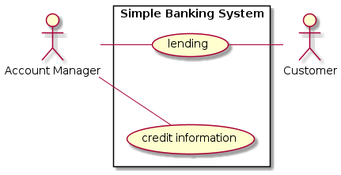

## Elements

- actors
  - represent a role of users
  - can be humans or external systems
- use cases
  - achieves a (business) goal of an actor
  - involvement of one or multiple actors
  - can include or extend each other
- system boundary
  - explicitly states what’s in or not

## Advanced Example

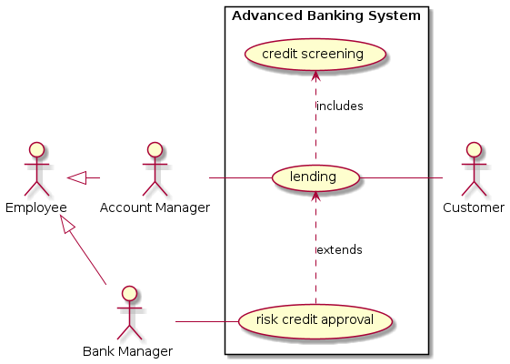

# PlantUML

## What is it?

- software tool to create simple UML diagrams
- no visual editing but specification by code
- automatic rendering and layouting

## Code Example

```
actor "Account Manager" as accountmgr
actor "Customer" as customer
actor "Bank Manager" as bankmgr

rectangle "Advanced Banking System" {
    usecase lending
    usecase "risk credit approval" as rca
    usecase "credit screening" as cs
}

lending -right- customer
lending -left- accountmgr
lending <.down. rca : extends
lending .up.> cs  : includes
rca -left- bankmgr
```

## Results in

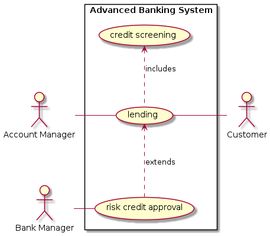

## How to develop

- Online Tools
  - http://www.plantuml.com
  - http://www.planttext.com
- Extensions / Plugins
  - IntelliJ
  - Visual Studio Code
  - and many more…